# Bank 6372 Project 2

Rashmi Patel

7/21/2021

```r
library(ellipsis)
library(tidyverse)
library(corrplot)
library(mlbench)
library(caret)
library(skimr)
library(mice)
library(purrr)
library(ggplot2)
library(ggthemes)
library(cowplot)
library(class)
library(e1071)
library(grid)
library(tidyr)
library(stringr)
library(naniar)
library(car)
library(MASS)
library(caret)
library(ROCR)
library(glmnet)
library(bestglm)
library(car)
library(ResourceSelection)
library(randomForest)
library('SmartEDA')
library(kableExtra)
library(DataExplorer)
```

# Load the data from Github

```r
bank=read_delim("https://raw.githubusercontent.com/RashmiAPatel19/SMU-6372-Applied-Stats/main/Project%202/data/bank-additional-full.csv", ";", escape_double = FALSE, trim_ws = TRUE)
bank
```

```
## # A tibble: 41,188 x 21
##      age job   marital education default housing loan  contact month day_of_week
##    <dbl> <chr> <chr>   <chr>     <chr>   <chr>   <chr> <chr>   <chr> <chr>
##  1    56 hous~ married basic.4y  no      no      no    teleph~ may   mon
##  2    57 serv~ married high.sch~ unknown no      no    teleph~ may   mon
##  3    37 serv~ married high.sch~ no      yes     no    teleph~ may   mon
##  4    40 admi~ married basic.6y  no      no      no    teleph~ may   mon
##  5    56 serv~ married high.sch~ no      no      yes   teleph~ may   mon
##  6    45 serv~ married basic.9y  unknown no      no    teleph~ may   mon
##  7    59 admi~ married professi~ no      no      no    teleph~ may   mon
##  8    41 blue~ married unknown   unknown no      no    teleph~ may   mon
##  9    24 tech~ single  professi~ no      yes     no    teleph~ may   mon
## 10    25 serv~ single  high.sch~ no      yes     no    teleph~ may   mon
## # ... with 41,178 more rows, and 11 more variables: duration <dbl>,
## #   campaign <dbl>, pdays <dbl>, previous <dbl>, poutcome <chr>,
## #   emp.var.rate <dbl>, cons.price.idx <dbl>, cons.conf.idx <dbl>,
## #   euribor3m <dbl>, nr.employed <dbl>, y <chr>
```

# Addressing Summary of the Bank data

```r
head(bank)
```

```
## # A tibble: 6 x 21
##     age job    marital education default housing loan  contact month day_of_week
##   <dbl> <chr>  <chr>   <chr>     <chr>   <chr>   <chr> <chr>   <chr> <chr>
## 1    56 house~ married basic.4y  no      no      no    teleph~ may   mon
## 2    57 servi~ married high.sch~ unknown no      no    teleph~ may   mon
## 3    37 servi~ married high.sch~ no      yes     no    teleph~ may   mon
## 4    40 admin. married basic.6y  no      no      no    teleph~ may   mon
## 5    56 servi~ married high.sch~ no      no      yes   teleph~ may   mon
## 6    45 servi~ married basic.9y  unknown no      no    teleph~ may   mon
## # ... with 11 more variables: duration <dbl>, campaign <dbl>, pdays <dbl>,
## #   previous <dbl>, poutcome <chr>, emp.var.rate <dbl>, cons.price.idx <dbl>,
## #   cons.conf.idx <dbl>, euribor3m <dbl>, nr.employed <dbl>, y <chr>
```

```r
tail(bank)
```

```
## # A tibble: 6 x 21
##     age job    marital education default housing loan  contact month day_of_week
##   <dbl> <chr>  <chr>   <chr>     <chr>   <chr>   <chr> <chr>   <chr> <chr>
## 1    29 unemp~ single  basic.4y  no      yes     no    cellul~ nov   fri
## 2    73 retir~ married professi~ no      yes     no    cellul~ nov   fri
## 3    46 blue-~ married professi~ no      no      no    cellul~ nov   fri
## 4    56 retir~ married universi~ no      yes     no    cellul~ nov   fri
## 5    44 techn~ married professi~ no      no      no    cellul~ nov   fri
## 6    74 retir~ married professi~ no      yes     no    cellul~ nov   fri
## # ... with 11 more variables: duration <dbl>, campaign <dbl>, pdays <dbl>,
## #   previous <dbl>, poutcome <chr>, emp.var.rate <dbl>, cons.price.idx <dbl>,
## #   cons.conf.idx <dbl>, euribor3m <dbl>, nr.employed <dbl>, y <chr>
```

```r
str(bank)
```

```
## spec_tbl_df [41,188 x 21] (S3: spec_tbl_df/tbl_df/tbl/data.frame)
##  $ age           : num [1:41188] 56 57 37 40 56 45 59 41 24 25 ...
##  $ job           : chr [1:41188] "housemaid" "services" "services" "admin." ...
##  $ marital       : chr [1:41188] "married" "married" "married" "married" ...
##  $ education     : chr [1:41188] "basic.4y" "high.school" "high.school" "basic.6y" ...
##  $ default       : chr [1:41188] "no" "unknown" "no" "no" ...
##  $ housing       : chr [1:41188] "no" "no" "yes" "no" ...
##  $ loan          : chr [1:41188] "no" "no" "no" "no" ...
##  $ contact       : chr [1:41188] "telephone" "telephone" "telephone" "telephone" ...
##  $ month         : chr [1:41188] "may" "may" "may" "may" ...
##  $ day_of_week   : chr [1:41188] "mon" "mon" "mon" "mon" ...
##  $ duration      : num [1:41188] 261 149 226 151 307 198 139 217 380 50 ...
##  $ campaign      : num [1:41188] 1 1 1 1 1 1 1 1 1 1 ...
##  $ pdays         : num [1:41188] 999 999 999 999 999 999 999 999 999 999 ...
##  $ previous      : num [1:41188] 0 0 0 0 0 0 0 0 0 0 ...
##  $ poutcome      : chr [1:41188] "nonexistent" "nonexistent" "nonexistent" "nonexistent" ...
##  $ emp.var.rate  : num [1:41188] 1.1 1.1 1.1 1.1 1.1 1.1 1.1 1.1 1.1 1.1 ...
##  $ cons.price.idx: num [1:41188] 94 94 94 94 94 ...
##  $ cons.conf.idx : num [1:41188] -36.4 -36.4 -36.4 -36.4 -36.4 -36.4 -36.4 -36.4 -36.4 -36.4 ...
##  $ euribor3m     : num [1:41188] 4.86 4.86 4.86 4.86 4.86 ...
##  $ nr.employed   : num [1:41188] 5191 5191 5191 5191 5191 ...
##  $ y             : chr [1:41188] "no" "no" "no" "no" ...
##  - attr(*, "spec")=
##   .. cols(
##   ..   age = col_double(),
##   ..   job = col_character(),
##   ..   marital = col_character(),
##   ..   education = col_character(),
##   ..   default = col_character(),
##   ..   housing = col_character(),
##   ..   loan = col_character(),
##   ..   contact = col_character(),
##   ..   month = col_character(),
##   ..   day_of_week = col_character(),
##   ..   duration = col_double(),
##   ..   campaign = col_double(),
##   ..   pdays = col_double(),
##   ..   previous = col_double(),
##   ..   poutcome = col_character(),
##   ..   emp.var.rate = col_double(),
##   ..   cons.price.idx = col_double(),
##   ..   cons.conf.idx = col_double(),
##   ..   euribor3m = col_double(),
##   ..   nr.employed = col_double(),
##   ..   y = col_character()
##   .. )
```

```r
dim(bank)
```

```
## [1] 41188    21
```

```r
names(bank)
```

```
##  [1] "age"            "job"            "marital"        "education"
##  [5] "default"        "housing"        "loan"           "contact"
##  [9] "month"          "day_of_week"    "duration"       "campaign"
## [13] "pdays"          "previous"       "poutcome"       "emp.var.rate"
## [17] "cons.price.idx" "cons.conf.idx"  "euribor3m"      "nr.employed"
## [21] "y"
```

```r
summary(bank)
```

```
##       age            job              marital           education
##  Min.   :17.00   Length:41188       Length:41188       Length:41188
##  1st Qu.:32.00   Class :character   Class :character   Class :character
##  Median :38.00   Mode  :character   Mode  :character   Mode  :character
##  Mean   :40.02
##  3rd Qu.:47.00
##  Max.   :98.00
##    default            housing              loan             contact
##  Length:41188       Length:41188       Length:41188       Length:41188
##  Class :character   Class :character   Class :character   Class :character
##  Mode  :character   Mode  :character   Mode  :character   Mode  :character
##
##
##
##     month           day_of_week           duration         campaign
##  Length:41188       Length:41188       Min.   :   0.0   Min.   : 1.000
##  Class :character   Class :character   1st Qu.: 102.0   1st Qu.: 1.000
##  Mode  :character   Mode  :character   Median : 180.0   Median : 2.000
##                                        Mean   : 258.3   Mean   : 2.568
##                                        3rd Qu.: 319.0   3rd Qu.: 3.000
##                                        Max.   :4918.0   Max.   :56.000
##      pdays          previous       poutcome          emp.var.rate
##  Min.   :  0.0   Min.   :0.000   Length:41188       Min.   :-3.40000
##  1st Qu.:999.0   1st Qu.:0.000   Class :character   1st Qu.:-1.80000
##  Median :999.0   Median :0.000   Mode  :character   Median : 1.10000
##  Mean   :962.5   Mean   :0.173                      Mean   : 0.08189
##  3rd Qu.:999.0   3rd Qu.:0.000                      3rd Qu.: 1.40000
##  Max.   :999.0   Max.   :7.000                      Max.   : 1.40000
##  cons.price.idx  cons.conf.idx     euribor3m      nr.employed
##  Min.   :92.20   Min.   :-50.8   Min.   :0.634   Min.   :4964
##  1st Qu.:93.08   1st Qu.:-42.7   1st Qu.:1.344   1st Qu.:5099
##  Median :93.75   Median :-41.8   Median :4.857   Median :5191
##  Mean   :93.58   Mean   :-40.5   Mean   :3.621   Mean   :5167
##  3rd Qu.:93.99   3rd Qu.:-36.4   3rd Qu.:4.961   3rd Qu.:5228
##  Max.   :94.77   Max.   :-26.9   Max.   :5.045   Max.   :5228
##       y
##  Length:41188
##  Class :character
##  Mode  :character
##
##
##
```

# Addressing missing values

- There is no missing values

```r
# Checking for missing values
sum(is.na(bank))
```

```
## [1] 0
```

# Addressing Character Variable and Numeric Variable

```r
# Checking the dimensions of the dataset
dim(bank)
```

```
## [1] 41188    21
```

```r
# Checking the column names of the dataset
colnames(bank)
```

```
##  [1] "age"            "job"            "marital"        "education"
##  [5] "default"        "housing"        "loan"           "contact"
##  [9] "month"          "day_of_week"    "duration"       "campaign"
## [13] "pdays"          "previous"       "poutcome"       "emp.var.rate"
## [17] "cons.price.idx" "cons.conf.idx"  "euribor3m"      "nr.employed"
## [21] "y"
```

```r
# Looking at the summary of the dataset
summary(bank)
```

```
##       age            job              marital           education
##  Min.   :17.00   Length:41188       Length:41188       Length:41188
##  1st Qu.:32.00   Class :character   Class :character   Class :character
##  Median :38.00   Mode  :character   Mode  :character   Mode  :character
##  Mean   :40.02
##  3rd Qu.:47.00
##  Max.   :98.00
##    default            housing              loan             contact
##  Length:41188       Length:41188       Length:41188       Length:41188
##  Class :character   Class :character   Class :character   Class :character
##  Mode  :character   Mode  :character   Mode  :character   Mode  :character
##
##
##
##     month           day_of_week           duration         campaign
##  Length:41188       Length:41188       Min.   :   0.0   Min.   : 1.000
##  Class :character   Class :character   1st Qu.: 102.0   1st Qu.: 1.000
##  Mode  :character   Mode  :character   Median : 180.0   Median : 2.000
##                                        Mean   : 258.3   Mean   : 2.568
##                                        3rd Qu.: 319.0   3rd Qu.: 3.000
##                                        Max.   :4918.0   Max.   :56.000
##      pdays          previous       poutcome          emp.var.rate
##  Min.   :  0.0   Min.   :0.000   Length:41188       Min.   :-3.40000
##  1st Qu.:999.0   1st Qu.:0.000   Class :character   1st Qu.:-1.80000
##  Median :999.0   Median :0.000   Mode  :character   Median : 1.10000
##  Mean   :962.5   Mean   :0.173                      Mean   : 0.08189
##  3rd Qu.:999.0   3rd Qu.:0.000                      3rd Qu.: 1.40000
##  Max.   :999.0   Max.   :7.000                      Max.   : 1.40000
##  cons.price.idx  cons.conf.idx     euribor3m      nr.employed
##  Min.   :92.20   Min.   :-50.8   Min.   :0.634   Min.   :4964
##  1st Qu.:93.08   1st Qu.:-42.7   1st Qu.:1.344   1st Qu.:5099
##  Median :93.75   Median :-41.8   Median :4.857   Median :5191
##  Mean   :93.58   Mean   :-40.5   Mean   :3.621   Mean   :5167
##  3rd Qu.:93.99   3rd Qu.:-36.4   3rd Qu.:4.961   3rd Qu.:5228
##  Max.   :94.77   Max.   :-26.9   Max.   :5.045   Max.   :5228
##       y
##  Length:41188
##  Class :character
##  Mode  :character
##
##
##
```

```r
# Checking for data types of the columns of the dataset
str(bank)
```

```
## spec_tbl_df [41,188 x 21] (S3: spec_tbl_df/tbl_df/tbl/data.frame)
##  $ age           : num [1:41188] 56 57 37 40 56 45 59 41 24 25 ...
##  $ job           : chr [1:41188] "housemaid" "services" "services" "admin." ...
##  $ marital       : chr [1:41188] "married" "married" "married" "married" ...
##  $ education     : chr [1:41188] "basic.4y" "high.school" "high.school" "basic.6y" ...
##  $ default       : chr [1:41188] "no" "unknown" "no" "no" ...
##  $ housing       : chr [1:41188] "no" "no" "yes" "no" ...
##  $ loan          : chr [1:41188] "no" "no" "no" "no" ...
##  $ contact       : chr [1:41188] "telephone" "telephone" "telephone" "telephone" ...
##  $ month         : chr [1:41188] "may" "may" "may" "may" ...
##  $ day_of_week   : chr [1:41188] "mon" "mon" "mon" "mon" ...
##  $ duration      : num [1:41188] 261 149 226 151 307 198 139 217 380 50 ...
##  $ campaign      : num [1:41188] 1 1 1 1 1 1 1 1 1 1 ...
##  $ pdays         : num [1:41188] 999 999 999 999 999 999 999 999 999 999 ...
##  $ previous      : num [1:41188] 0 0 0 0 0 0 0 0 0 0 ...
##  $ poutcome      : chr [1:41188] "nonexistent" "nonexistent" "nonexistent" "nonexistent" ...
##  $ emp.var.rate  : num [1:41188] 1.1 1.1 1.1 1.1 1.1 1.1 1.1 1.1 1.1 1.1 ...
##  $ cons.price.idx: num [1:41188] 94 94 94 94 94 ...
##  $ cons.conf.idx : num [1:41188] -36.4 -36.4 -36.4 -36.4 -36.4 -36.4 -36.4 -36.4 -36.4 -36.4 ...
##  $ euribor3m     : num [1:41188] 4.86 4.86 4.86 4.86 4.86 ...
##  $ nr.employed   : num [1:41188] 5191 5191 5191 5191 5191 ...
##  $ y             : chr [1:41188] "no" "no" "no" "no" ...
##  - attr(*, "spec")=
##   .. cols(
##   ..   age = col_double(),
##   ..   job = col_character(),
##   ..   marital = col_character(),
##   ..   education = col_character(),
##   ..   default = col_character(),
##   ..   housing = col_character(),
##   ..   loan = col_character(),
##   ..   contact = col_character(),
##   ..   month = col_character(),
##   ..   day_of_week = col_character(),
##   ..   duration = col_double(),
##   ..   campaign = col_double(),
##   ..   pdays = col_double(),
##   ..   previous = col_double(),
##   ..   poutcome = col_character(),
##   ..   emp.var.rate = col_double(),
##   ..   cons.price.idx = col_double(),
##   ..   cons.conf.idx = col_double(),
##   ..   euribor3m = col_double(),
##   ..   nr.employed = col_double(),
##   ..   y = col_character()
##   .. )
```

```r
# Checking for number of columns with numeric type
numeric_var_who=sum(sapply(bank[,1:21],is.numeric))
numeric_var_who
```

```
## [1] 10
```

```r
# Checking for number of columns with character type
char_var_who=sum(sapply(bank[,1:21],is.character))
char_var_who
```

```
## [1] 11
```

```r
# Checking for column names with numeric type
numeric_varname_who=which(sapply(bank[,1:21],is.numeric))
numeric_varname_who
```

```
##            age       duration       campaign          pdays       previous
##              1             11             12             13             14
##   emp.var.rate cons.price.idx  cons.conf.idx      euribor3m    nr.employed
##             16             17             18             19             20
```

```r
# Checking for column names with character type
char_varname_who=which(sapply(bank[,1:21],is.character))
char_varname_who
```

```
##         job     marital   education     default     housing        loan
##           2           3           4           5           6           7
##     contact       month day_of_week    poutcome           y
##           8           9          10          15          21
```

# Looking at the normality of Numeric Variables

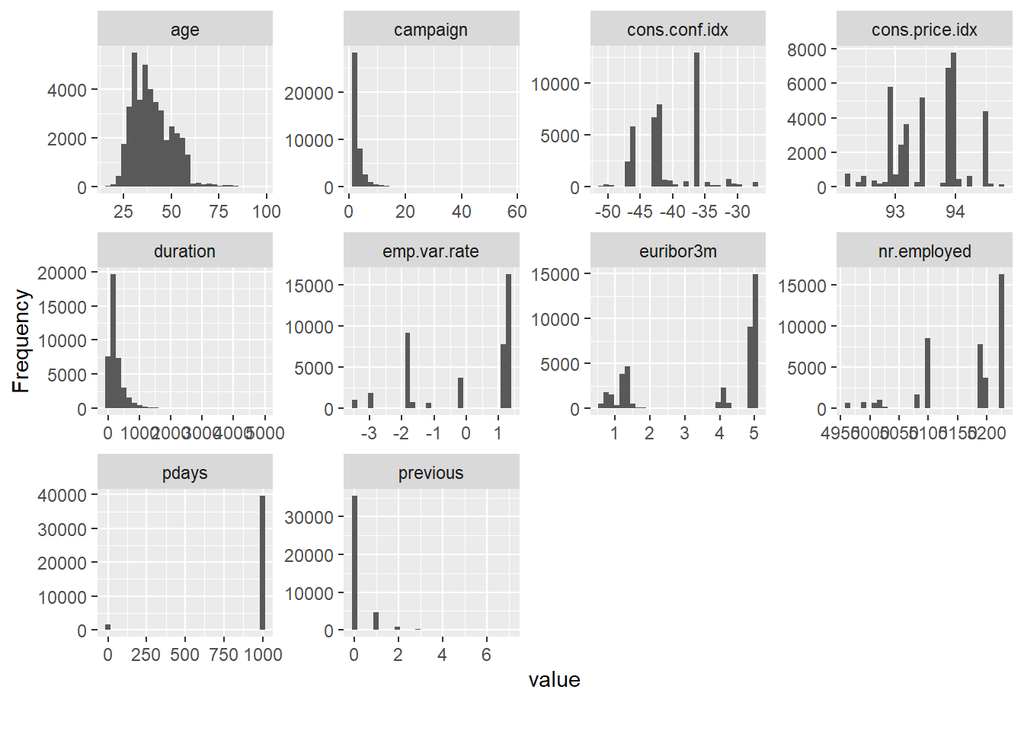

```r
plot_histogram(bank)
```

# Looking at the graph for Response variable

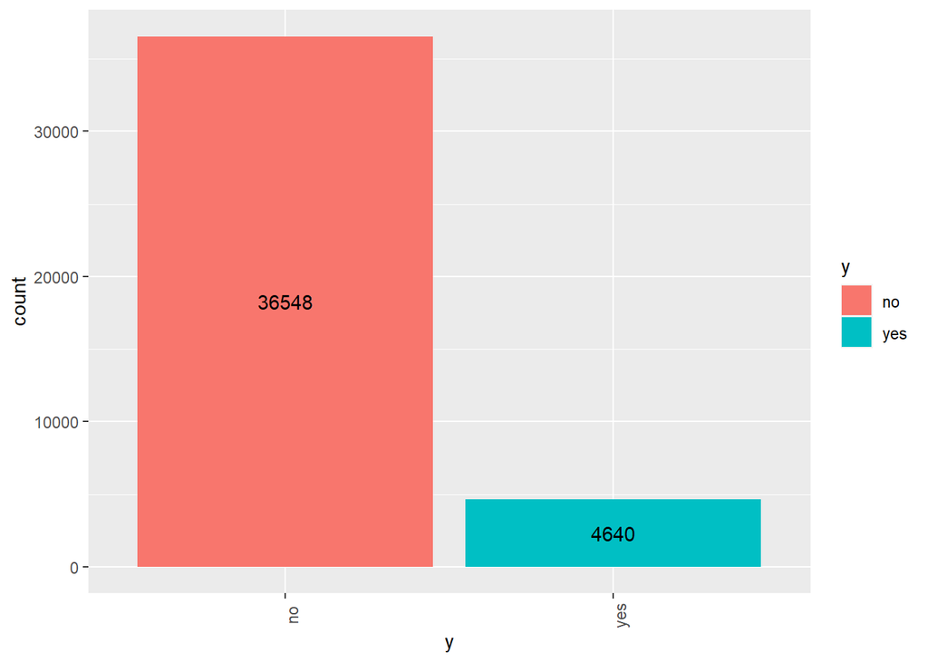

```r
ggplot(bank,aes(x=y,fill=y))+geom_bar(position="stack",stat="count")+
  theme(axis.text.x = element_text(angle = 90))+geom_text(aes(label=..count..),stat="count",position=position_stack(0.5))
```

#

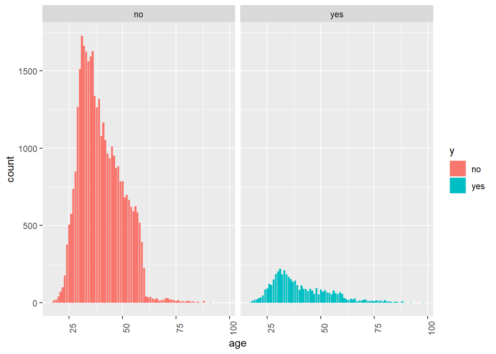

```r
# Age vs Response
ggplot(bank,aes(x=age,fill=y))+geom_bar(position="stack",stat="count")+
  theme(axis.text.x = element_text(angle = 90))+facet_wrap(~y)
```

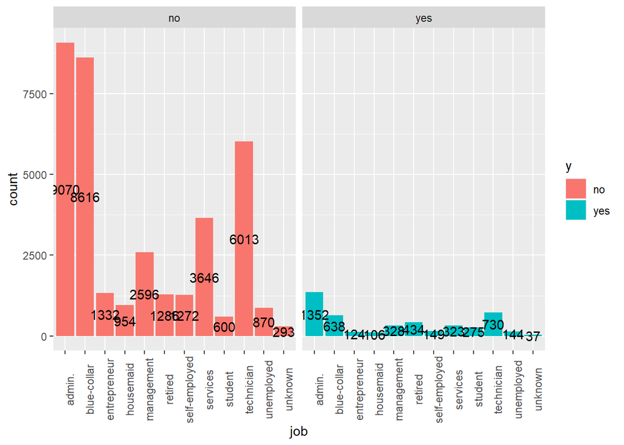

```r
# Job vs Response
ggplot(bank,aes(x=job,fill=y))+geom_bar(position="stack",stat="count")+
  theme(axis.text.x = element_text(angle=90))+facet_wrap(~y)+
  geom_text(aes(label=..count..),stat="count",position=position_stack(0.5))
```

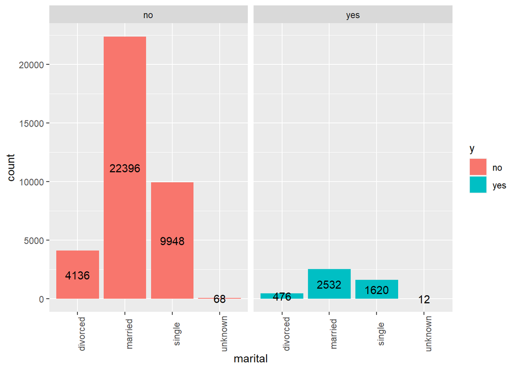

```r
# Marital Status vs Response
ggplot(bank,aes(x=marital,fill=y))+geom_bar(position="stack",stat="count")+
  theme(axis.text.x = element_text(angle = 90))+facet_wrap(~y)+
  geom_text(aes(label=..count..),stat="count",position=position_stack(0.5))
```

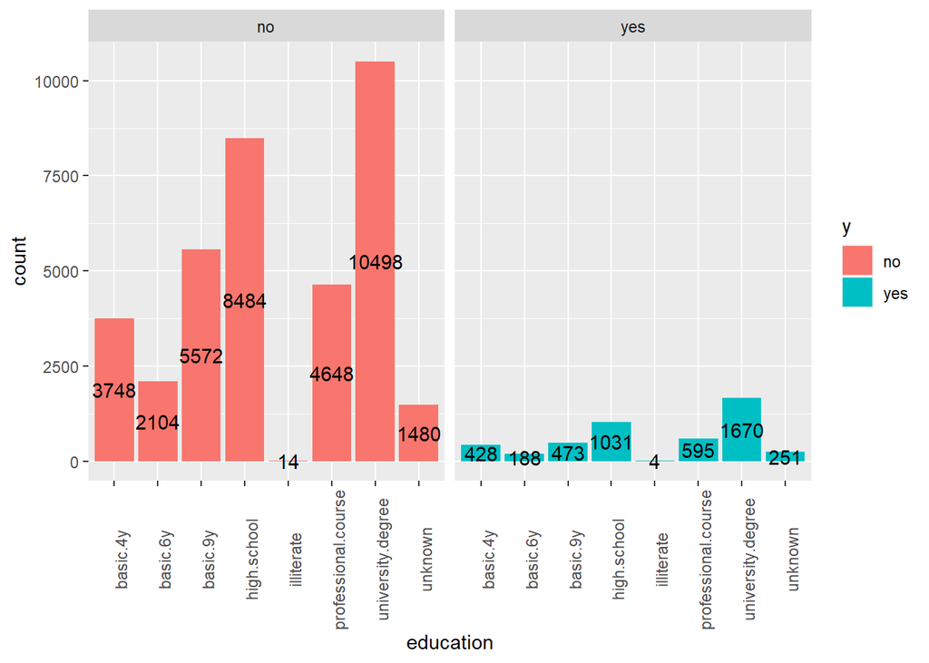

```r
# Education vs Response
ggplot(bank,aes(x=education,fill=y))+geom_bar(position="stack",stat="count")+
  theme(axis.text.x = element_text(angle = 90))+facet_wrap(~y)+
  geom_text(aes(label=..count..),stat="count",position=position_stack(0.5))
```

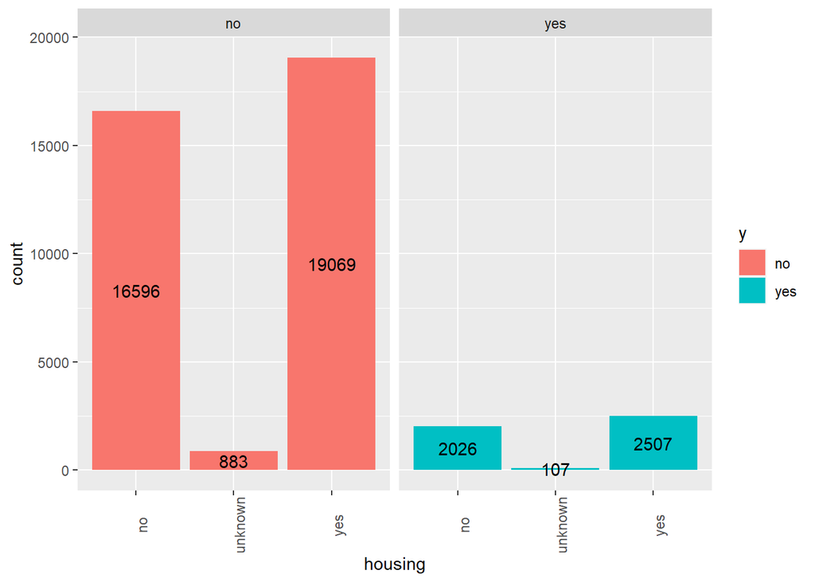

```r
# Housing vs Response
ggplot(bank,aes(x=housing,fill=y))+geom_bar(position="stack",stat="count")+
  theme(axis.text.x = element_text(angle = 90))+facet_wrap(~y)+
  geom_text(aes(label=..count..),stat="count",position=position_stack(0.5))
```

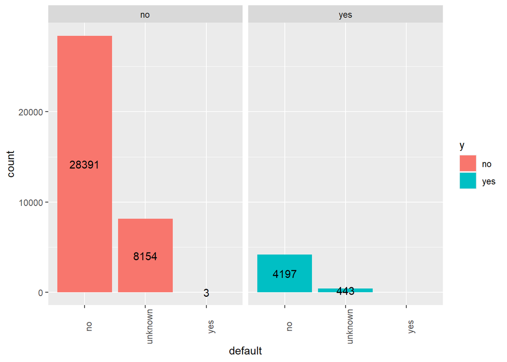

```r
# Default vs Response
ggplot(bank,aes(x=default,fill=y))+geom_bar(position="stack",stat="count")+
  theme(axis.text.x = element_text(angle = 90))+facet_wrap(~y)+
  geom_text(aes(label=..count..),stat="count",position=position_stack(0.5))
```

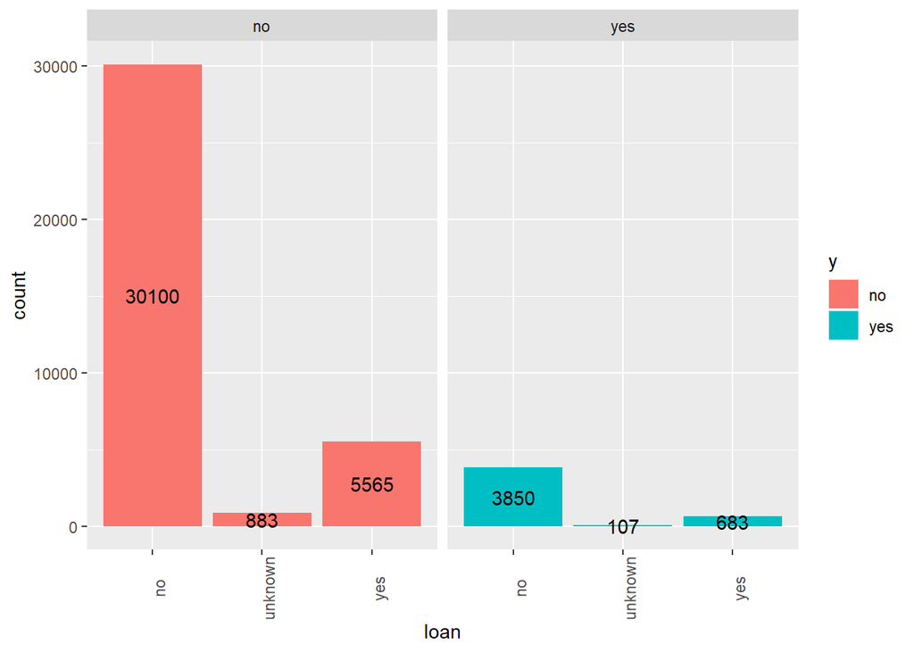

```r
# Loan vs Response
ggplot(bank,aes(x=loan,fill=y))+geom_bar(position="stack",stat="count")+
  theme(axis.text.x = element_text(angle = 90))+facet_wrap(~y)+
  geom_text(aes(label=..count..),stat="count",position=position_stack(0.5))
```

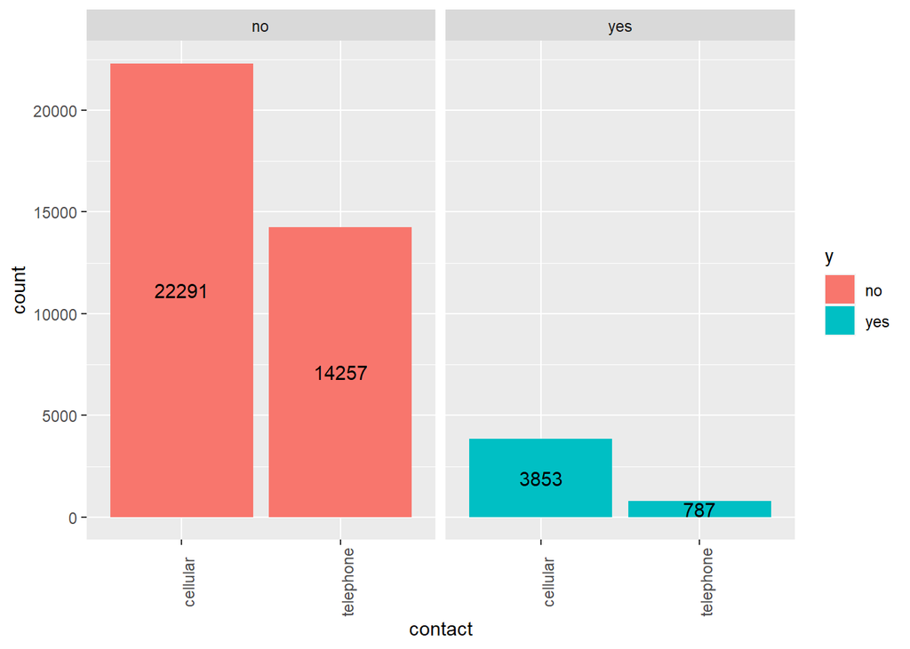

```r
# Contact vs Response
ggplot(bank,aes(x=contact,fill=y))+geom_bar(position="stack",stat="count")+
  theme(axis.text.x = element_text(angle = 90))+facet_wrap(~y)+
  geom_text(aes(label=..count..),stat="count",position=position_stack(0.5))
```

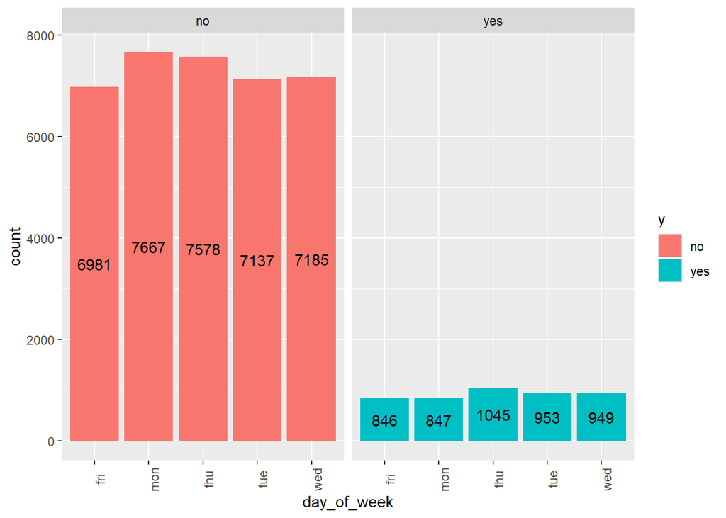

```r
# Day of the week vs Response
ggplot(bank,aes(x=day_of_week,fill=y))+geom_bar(position="stack",stat="count")+
  theme(axis.text.x = element_text(angle = 90))+facet_wrap(~y)+
  geom_text(aes(label=..count..),stat="count",position=position_stack(0.5))
```

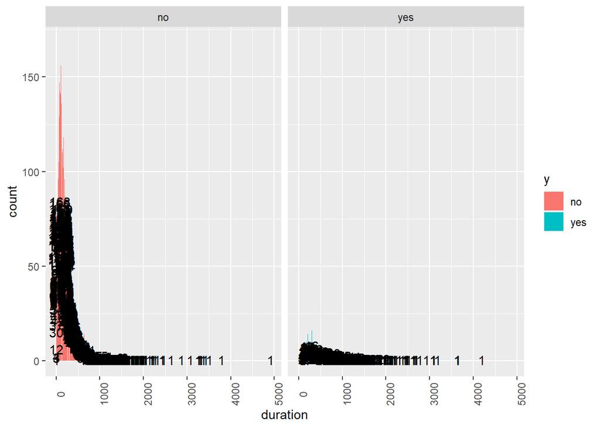

```r
# Duration vs Response
ggplot(bank,aes(x=duration,fill=y))+geom_bar(position="stack",stat="count")+
  theme(axis.text.x = element_text(angle = 90))+facet_wrap(~y)+
  geom_text(aes(label=..count..),stat="count",position=position_stack(0.5))
```

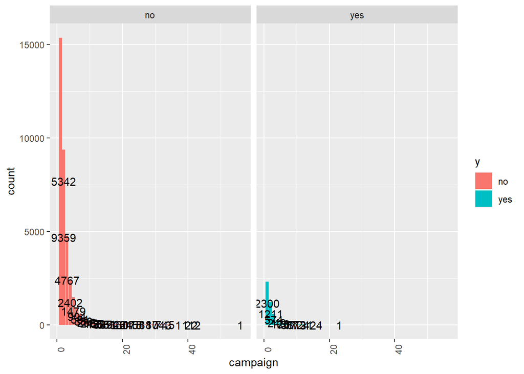

```r
# Campaign vs Response
ggplot(bank,aes(x=campaign,fill=y))+geom_bar(position="stack",stat="count")+
  theme(axis.text.x = element_text(angle = 90))+facet_wrap(~y)+
  geom_text(aes(label=..count..),stat="count",position=position_stack(0.5))
```

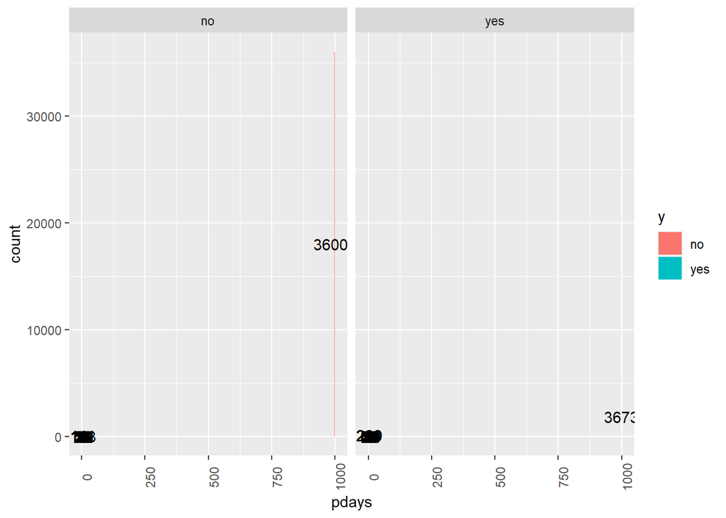

```r
# Pdays vs Response
ggplot(bank,aes(x=pdays,fill=y))+geom_bar(position="stack",stat="count")+
  theme(axis.text.x = element_text(angle = 90))+facet_wrap(~y)+
  geom_text(aes(label=..count..),stat="count",position=position_stack(0.5))
```

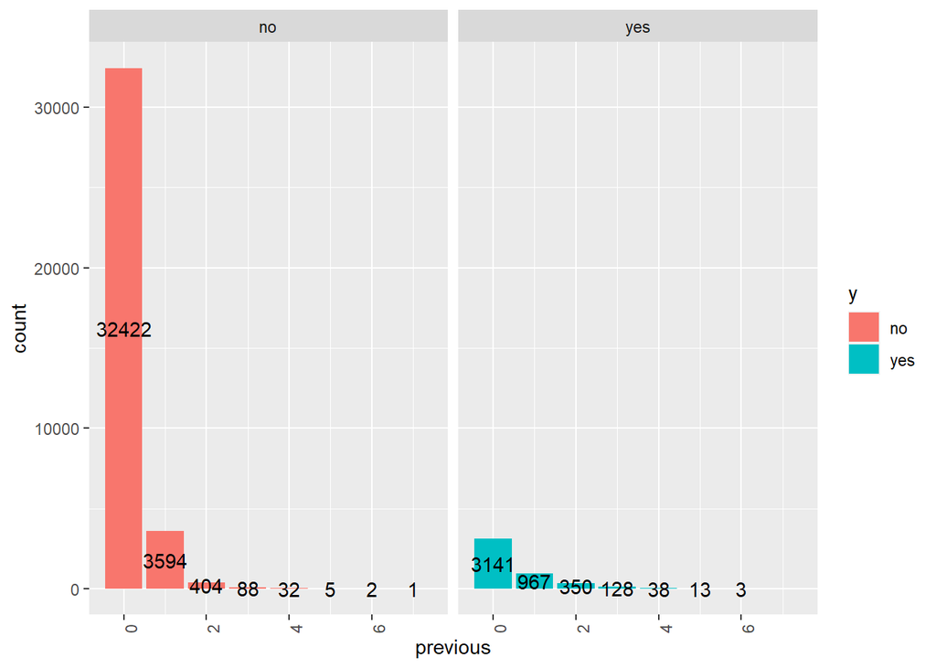

```r
# Previous vs Response
ggplot(bank,aes(x=previous,fill=y))+geom_bar(position="stack",stat="count")+
  theme(axis.text.x = element_text(angle = 90))+facet_wrap(~y)+
  geom_text(aes(label=..count..),stat="count",position=position_stack(0.5))
```

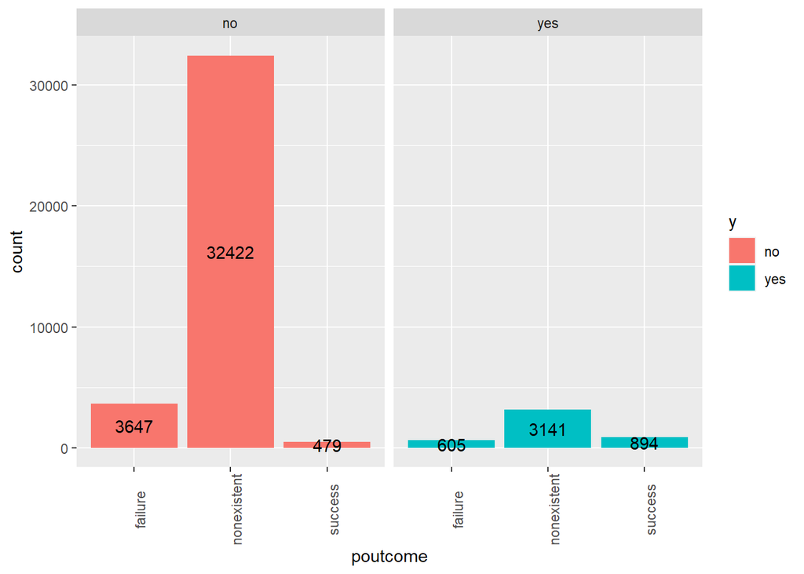

```r
# Poutcome vs Response
ggplot(bank,aes(x=poutcome,fill=y))+geom_bar(position="stack",stat="count")+
  theme(axis.text.x = element_text(angle = 90))+facet_wrap(~y)+
  geom_text(aes(label=..count..),stat="count",position=position_stack(0.5))
```

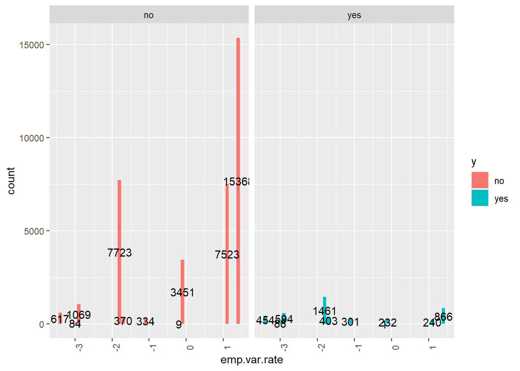

```r
# Emp.var.Rate vs Response
ggplot(bank,aes(x=emp.var.rate,fill=y))+geom_bar(position="stack",stat="count")+
  theme(axis.text.x = element_text(angle = 90))+facet_wrap(~y)+
  geom_text(aes(label=..count..),stat="count",position=position_stack(0.5))
```

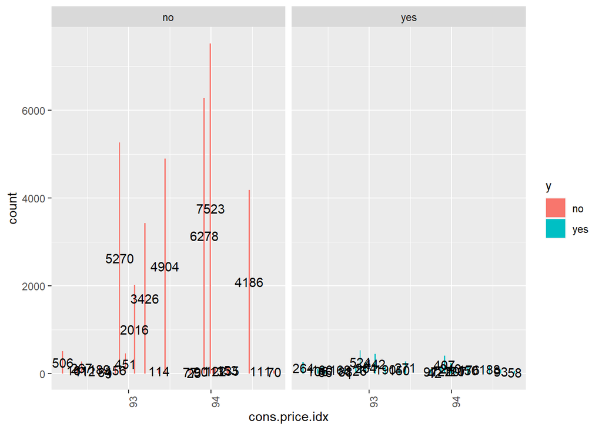

```r
# Cons.price.idx vs Response
ggplot(bank,aes(x=cons.price.idx,fill=y))+geom_bar(position="stack",stat="count")+
  theme(axis.text.x = element_text(angle = 90))+facet_wrap(~y)+
  geom_text(aes(label=..count..),stat="count",position=position_stack(0.5))
```

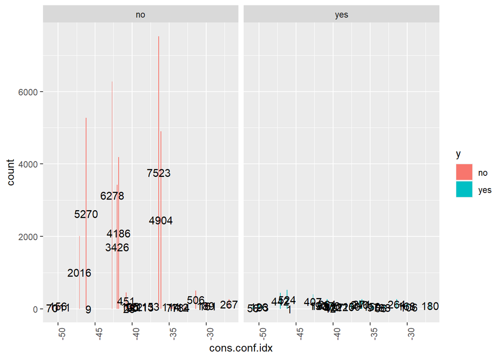

```r
# Cons.conf.idx vs Response
ggplot(bank,aes(x=cons.conf.idx,fill=y))+geom_bar(position="stack",stat="count")+
  theme(axis.text.x = element_text(angle = 90))+facet_wrap(~y)+
  geom_text(aes(label=..count..),stat="count",position=position_stack(0.5))
```

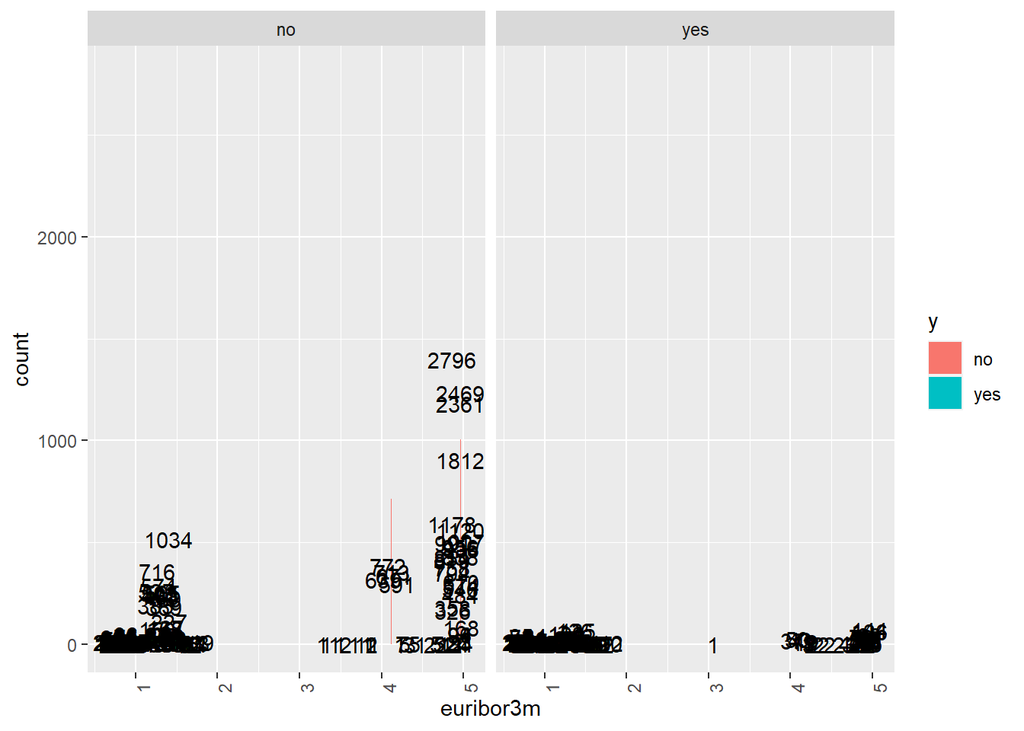

```r
# Euribor3m vs Response
ggplot(bank,aes(x=euribor3m,fill=y))+geom_bar(position="stack",stat="count")+
  theme(axis.text.x = element_text(angle = 90))+facet_wrap(~y)+
  geom_text(aes(label=..count..),stat="count",position=position_stack(0.5))
```

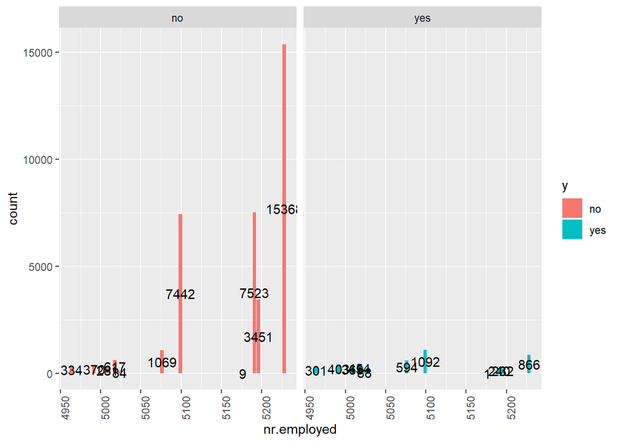

```r
# nr.employed vs Response
ggplot(bank,aes(x=nr.employed,fill=y))+geom_bar(position="stack",stat="count")+
  theme(axis.text.x = element_text(angle = 90))+facet_wrap(~y)+
  geom_text(aes(label=..count..),stat="count",position=position_stack(0.5))
```

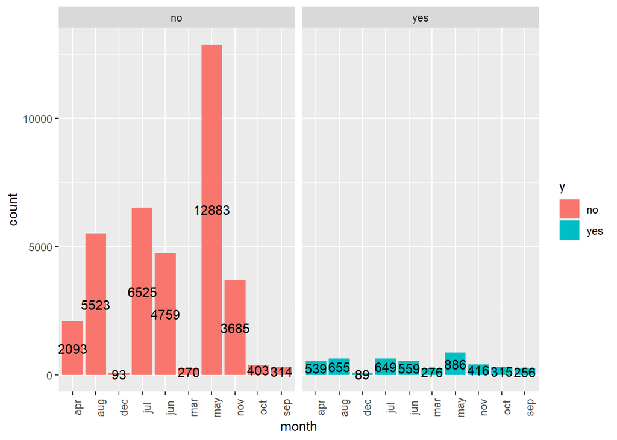

```r
# Month vs Response
ggplot(bank,aes(x=month,fill=y))+geom_bar(position="stack",stat="count")+
  theme(axis.text.x = element_text(angle = 90))+facet_wrap(~y)+
  geom_text(aes(label=..count..),stat="count",position=position_stack(0.5))
```

This table shows the correlation between the numerical variables

- nr.employed and emp.var.rate are 91% correlated.
- nr.employed and euribor3m are 95% correlated.
- emp.var.rate and euribor3m are 97% correlated.
- cons.price.idx and emp.var.rate are 78% correlated.
- cons.price.idx and euribor3m are 69% correlated.
- cons.price.idx and nr.employed are 52% correlated.

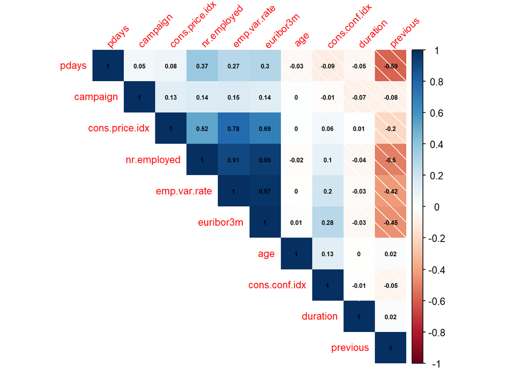

```r
corrdfTraintable <- bank %>% keep(is.numeric) %>% na.omit %>% cor %>% view

bank %>% keep(is.numeric) %>% na.omit %>% cor %>% corrplot("upper", addCoef.col = "black", number.digits = 2, number.cex = 0.5, method="shade", order = "hclust", tl.srt=45, tl.cex = 0.8)
```

```r
view(corrdfTraintable)
```

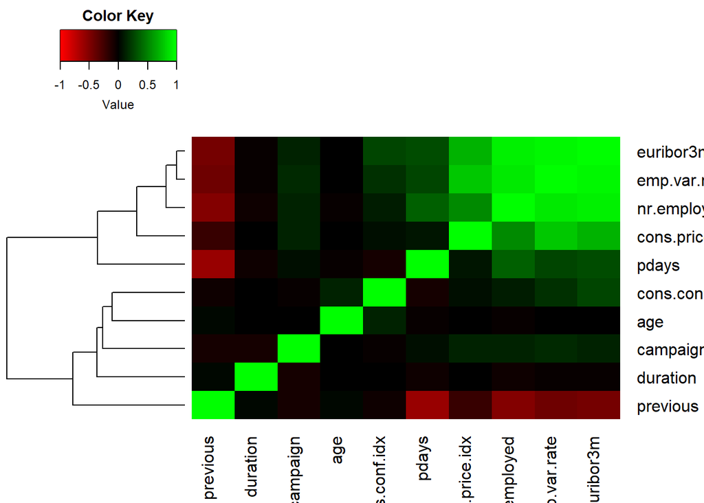

```r
my.cor <- cor(bank %>% keep(is.numeric) %>% na.omit)

library(gplots)
library(ggplot2)
heatmap.2(my.cor,col=redgreen(75),
          density.info="none", trace="none", dendrogram=c("row"),
          symm=F,symkey=T,symbreaks=T, scale="none")
```

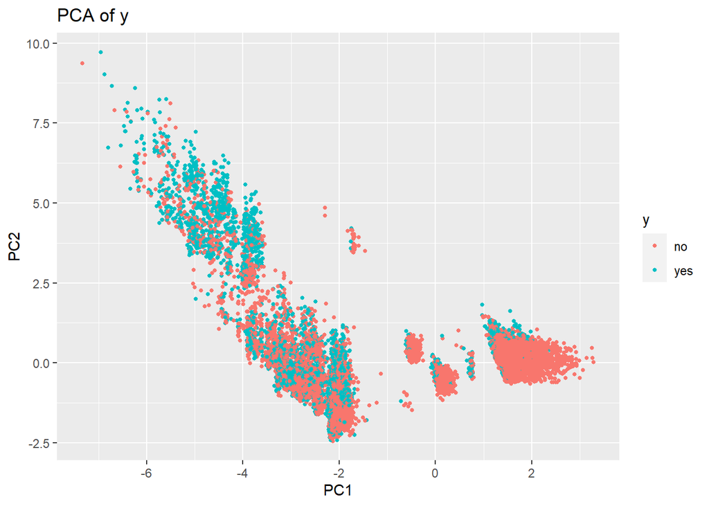

```r
#Another option here would be to do PCA among the continous predictors to see
#if they seperate out.  Or a heatmap.
pc.result<-prcomp(bank %>% keep(is.numeric) %>% na.omit,scale.=TRUE)
pc.scores<-pc.result$x
pc.scores<-data.frame(pc.scores)
pc.scores$y<-bank$y


#Use ggplot2 to plot the first few pc's
ggplot(data = pc.scores, aes(x = PC1, y = PC2)) +
  geom_point(aes(col=y), size=1)+
  ggtitle("PCA of y")
```

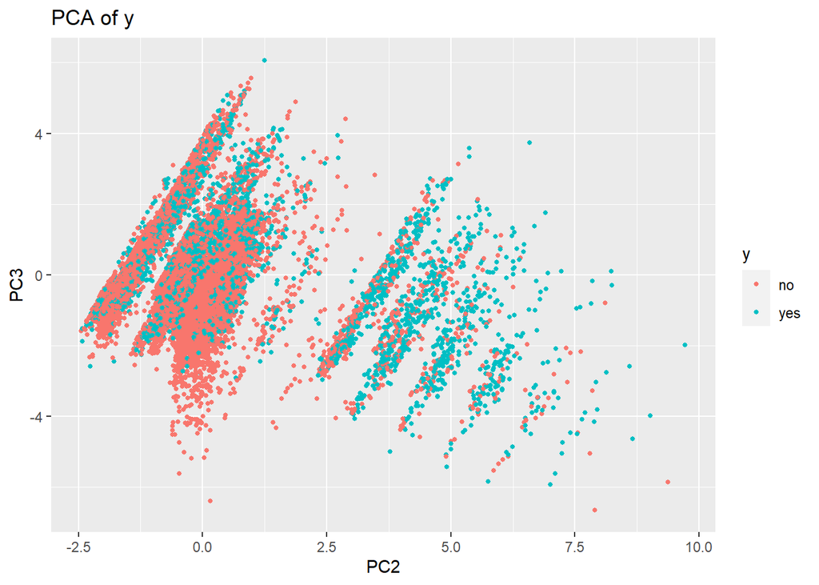

```r
ggplot(data = pc.scores, aes(x = PC2, y = PC3)) +
  geom_point(aes(col=y), size=1)+
  ggtitle("PCA of y")
```

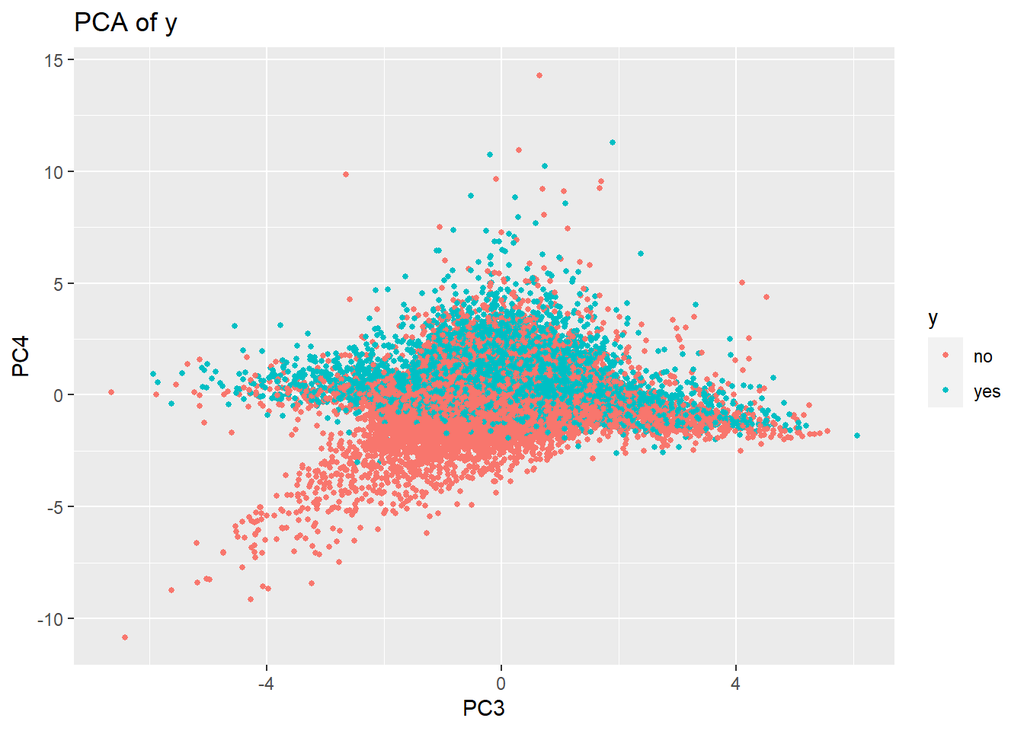

```r
ggplot(data = pc.scores, aes(x = PC3, y = PC4)) +
  geom_point(aes(col=y), size=1)+
  ggtitle("PCA of y")
```

```r
# we don't really see much separation with PCA
```

Missing values are disguised as unknown values in the data set and we devised a code to show them all

default 8597 education 1731 housing 990 loan 990 job 330 marital 80

For Marital, housing and job it is safe to remove the unknown values as they’re so little they won’t have an effect on the rest of the distribution

- Looking at default is has no information as it is highly skewed towards “no” as only 3 counts comes up as “yes” so we are removing “default” as well.

```r
bank %>%
  summarise_all(list(~sum(. == "unknown"))) %>%
  gather(key = "variable", value = "nr_unknown") %>%
  arrange(-nr_unknown)
```

```
## # A tibble: 21 x 2
##    variable    nr_unknown
##    <chr>            <int>
##  1 default           8597
##  2 education         1731
##  3 housing            990
##  4 loan               990
##  5 job                330
##  6 marital             80
##  7 age                  0
##  8 contact              0
##  9 month                0
## 10 day_of_week          0
## # ... with 11 more rows
```

```r
summary(bank$job)
```

```
##    Length     Class      Mode
##     41188 character character
```

```r
summary(bank$default)
```

```
##    Length     Class      Mode
##     41188 character character
```

```r
summary(bank$education)
```

```
##    Length     Class      Mode
##     41188 character character
```

```r
summary(bank$loan)
```

```
##    Length     Class      Mode
##     41188 character character
```

```r
summary(bank$marital)
```

```
##    Length     Class      Mode
##     41188 character character
```

```r
summary(bank$housing)
```

```
##    Length     Class      Mode
##     41188 character character
```

```r
bank <- subset(bank, job!="unknown")
bank <- subset(bank, marital!="unknown")
bank <- subset(bank, housing!="unknown")
bank <- subset(bank, loan!="unknown")
bank <- subset(bank, default!="unknown")
bank <- subset(bank, education!="unknown")
```

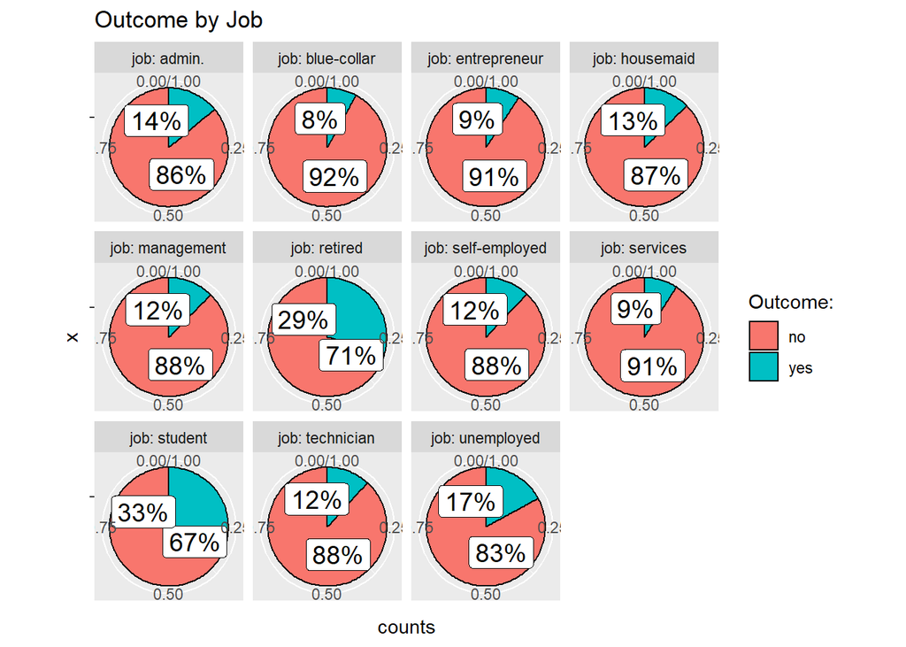

```r
library("dplyr")
ShowPieChart <- function(columnBy, columnToShow, titleName)
{
  df <- dplyr::group_by(bank, .dots = c(columnBy, columnToShow)) %>%
    dplyr::summarize(counts = n()) %>%
    dplyr::mutate(perc = (counts / sum(counts)) * 100) %>%
    dplyr::arrange_(.dots=c(columnBy, columnToShow))


  # preparing the plot
  ggplot2::ggplot(df, aes('', counts)) +
    geom_col(
      position = 'fill',
      color = 'black',
      width = 1,
      aes(fill = y)
    ) +
    ggtitle(titleName) +
    facet_wrap(paste("~",columnBy), labeller = "label_both") +
    geom_label(
      aes(label = paste0(round(perc), "%"), group = "y"),
      position = position_fill(vjust = 0.5),
      color = 'black',
      size = 5,
      show.legend = FALSE
    ) + scale_fill_discrete(name = "Outcome:") +
    coord_polar(theta = "y")
}
ShowPieChart("job", "y", "Outcome by Job")
```

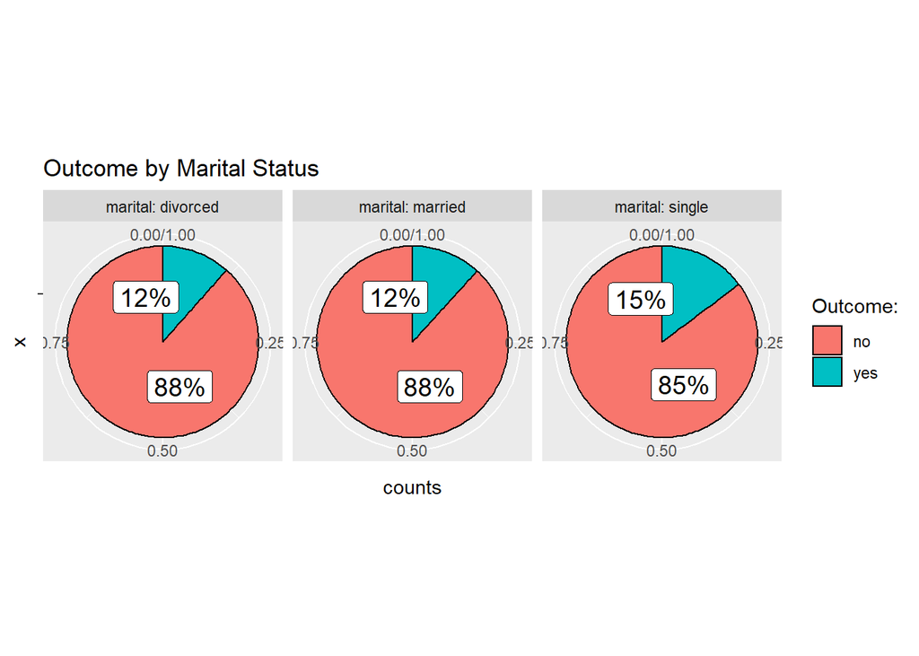

```r
ShowPieChart("marital", "y", "Outcome by Marital Status")
```

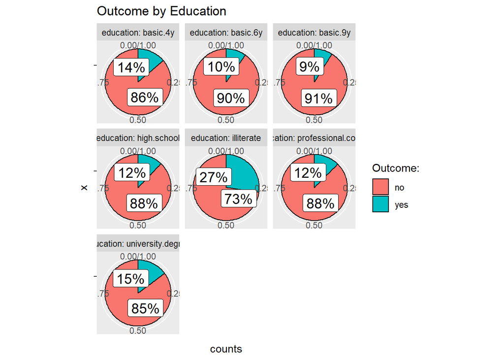

```r
ShowPieChart("education", "y", "Outcome by Education")
```

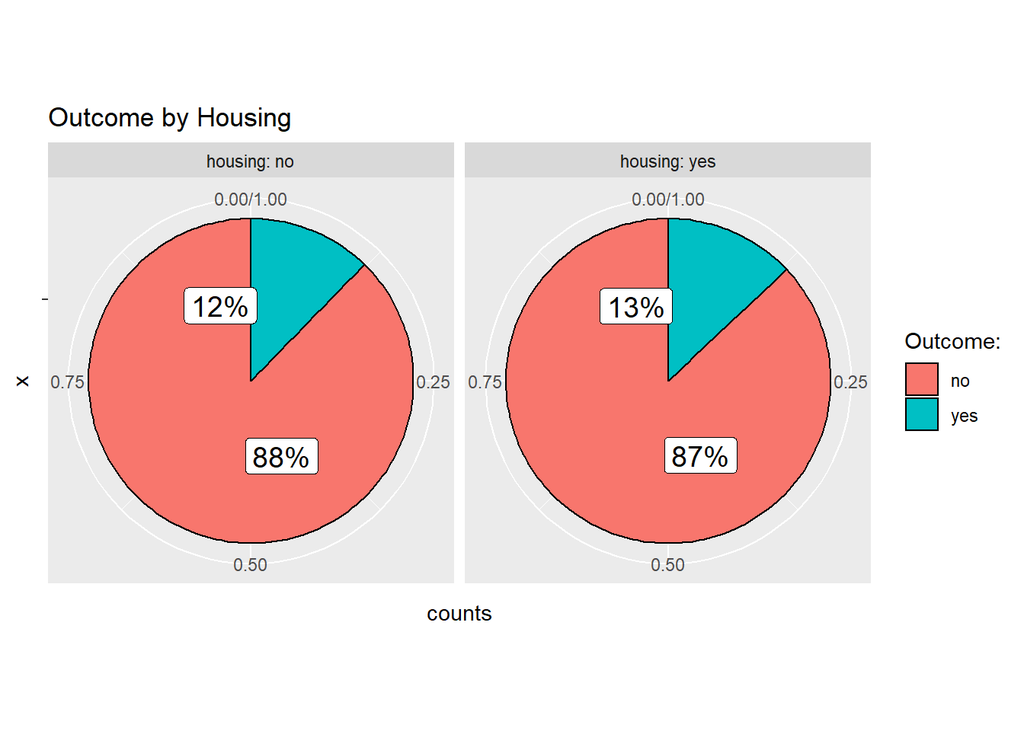

```r
ShowPieChart("housing", "y", "Outcome by Housing")
```

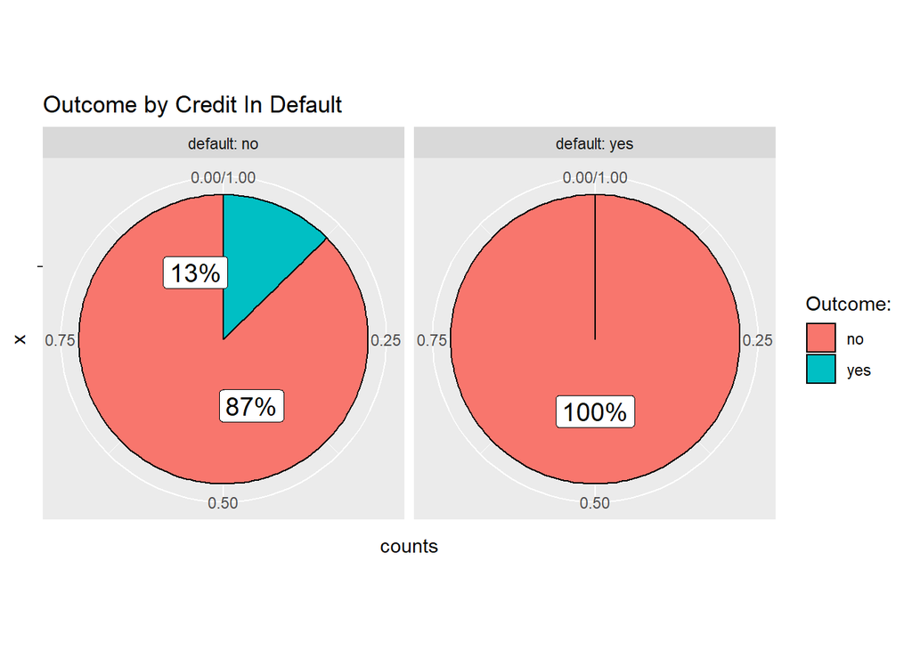

```r
ShowPieChart("default", "y", "Outcome by Credit In Default")
```

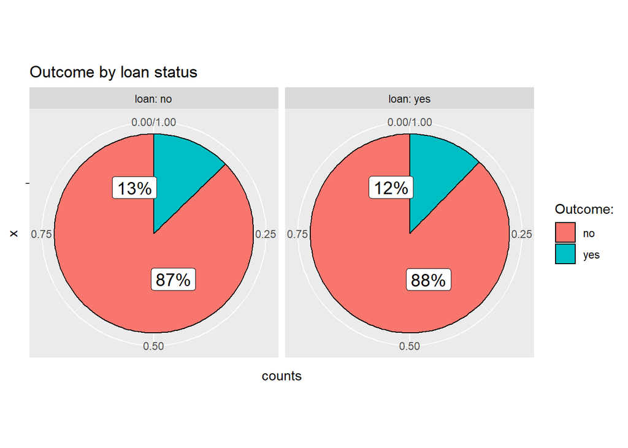

```r
ShowPieChart("loan", "y", "Outcome by loan status")
```

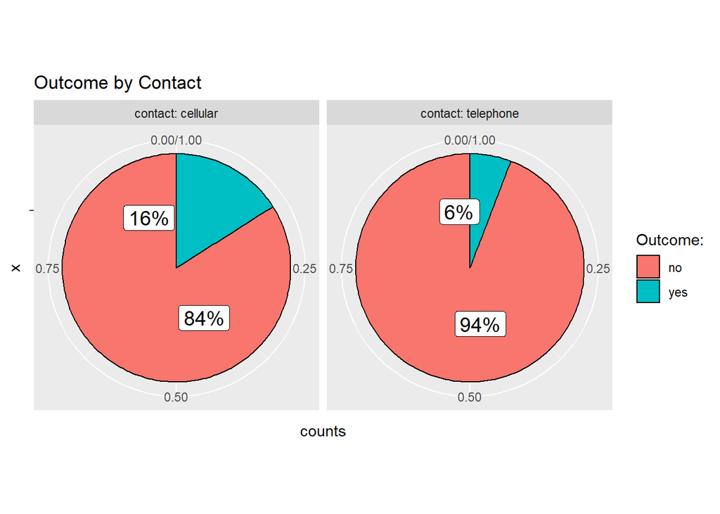

```r
ShowPieChart("contact", "y", "Outcome by Contact")
```

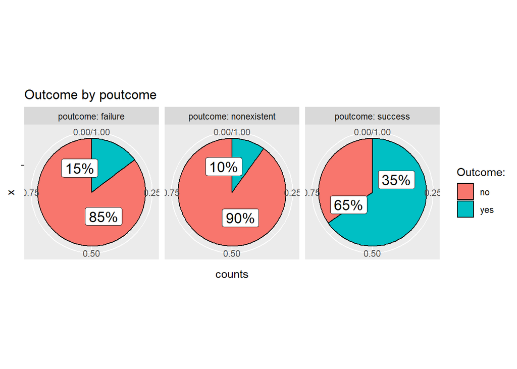

```r
ShowPieChart("poutcome", "y", "Outcome by poutcome")
```